# R Notebook

Build a multiple linear regression model, `AveragePrice` on avocados.Predictors? (coor) Validation techniques (from Wednesday) to evaluated. Explanatory/ predictive model? Interpreting the results and write your comments in your script

Resume. I think I did a bad tidy/ cleaning, My results are poor and I feel I did not choose the correct predictors

```r
library(GGally) #visualisation/ggpairs
library(modelr)
library(janitor)
library(lubridate)
library(tidyverse)
```

```r
avocado <-  read_csv('data/avocado.csv') %>% clean_names()
view(avocado)
```

```r
#check the variables  for NA, class..
#PLU show the size of the avocado, 4046: small,4225:Large,4770: all size.
#Total_volume != sum(4046,4225,4770)
#X1 : noise variable
#date: is not necessary but it can be split in quarters for what?


summary(avocado)
```

```
       x1             date            average_price
 Min.   : 0.00   Min.   :2015-01-04   Min.   :0.440
 1st Qu.:10.00   1st Qu.:2015-10-25   1st Qu.:1.100
 Median :24.00   Median :2016-08-14   Median :1.370
 Mean   :24.23   Mean   :2016-08-13   Mean   :1.406
 3rd Qu.:38.00   3rd Qu.:2017-06-04   3rd Qu.:1.660
 Max.   :52.00   Max.   :2018-03-25   Max.   :3.250
  total_volume          x4046              x4225
 Min.   :      85   Min.   :       0   Min.   :       0
 1st Qu.:   10839   1st Qu.:     854   1st Qu.:    3009
 Median :  107377   Median :    8645   Median :   29061
 Mean   :  850644   Mean   :  293008   Mean   :  295155
 3rd Qu.:  432962   3rd Qu.:  111020   3rd Qu.:  150207
 Max.   :62505647   Max.   :22743616   Max.   :20470573
     x4770           total_bags         small_bags
 Min.   :      0   Min.   :       0   Min.   :       0
 1st Qu.:      0   1st Qu.:    5089   1st Qu.:    2849
 Median :    185   Median :   39744   Median :   26363
 Mean   :  22840   Mean   :  239639   Mean   :  182195
 3rd Qu.:   6243   3rd Qu.:  110783   3rd Qu.:   83338
 Max.   :2546439   Max.   :19373134   Max.   :13384587
   large_bags       x_large_bags          type
 Min.   :      0   Min.   :     0.0   Length:18249
 1st Qu.:    127   1st Qu.:     0.0   Class :character
 Median :   2648   Median :     0.0   Mode  :character
 Mean   :  54338   Mean   :  3106.4
 3rd Qu.:  22029   3rd Qu.:   132.5
 Max.   :5719097   Max.   :551693.7
      year         region
 Min.   :2015   Length:18249
 1st Qu.:2015   Class :character
 Median :2016   Mode  :character
 Mean   :2016
 3rd Qu.:2017
 Max.   :2018
```

Transforming variable date

```r
avocado <- avocado %>%
  mutate(date = ymd(date),
         month_enter = month(date, label = TRUE, abbr = FALSE),
         year_enter = year(date),
         day_enter = day(date),
  )
```

```r
avocado <- avocado %>%
  mutate(quarters = case_when(
    month_enter %in% c('January','February','March')~ "Q1",
    month_enter %in% c('April','May', 'June') ~ "Q2",
    month_enter %in% c('July','August','September') ~ "Q3",
    month_enter %in% c('October', 'November', 'December')~ "Q4",
  ))
avocado
```

| x1 | date | average_price | total_volume | x4046 | x4225 | x4770 | total_bags | small_bags | large_bags | x_large_bags | type | year | region | month_enter | year_enter | day_enter | quarters |
| --- | --- | --- | --- | --- | --- | --- | --- | --- | --- | --- | --- | --- | --- | --- | --- | --- | --- |
| 0 | 2015-12-27 | 1.33 | 64236.62 | 1036.74 | 54454.85 | 48.16 | 8696.87 | 8603.62 | 93.25 | 0.00 | conventional | 2015 | Albany | December | 2015 | 27 | Q4 |
| 1 | 2015-12-20 | 1.35 | 54876.98 | 674.28 | 44638.81 | 58.33 | 9505.56 | 9408.07 | 97.49 | 0.00 | conventional | 2015 | Albany | December | 2015 | 20 | Q4 |
| 2 | 2015-12-13 | 0.93 | 118220.22 | 794.70 | 109149.67 | 130.50 | 8145.35 | 8042.21 | 103.14 | 0.00 | conventional | 2015 | Albany | December | 2015 | 13 | Q4 |
| 3 | 2015-12-06 | 1.08 | 78992.15 | 1132.00 | 71976.41 | 72.58 | 5811.16 | 5677.40 | 133.76 | 0.00 | conventional | 2015 | Albany | December | 2015 | 6 | Q4 |
| 4 | 2015-11-29 | 1.28 | 51039.60 | 941.48 | 43838.39 | 75.78 | 6183.95 | 5986.26 | 197.69 | 0.00 | conventional | 2015 | Albany | November | 2015 | 29 | Q4 |
| 5 | 2015-11-22 | 1.26 | 55979.78 | 1184.27 | 48067.99 | 43.61 | 6683.91 | 6556.47 | 127.44 | 0.00 | conventional | 2015 | Albany | November | 2015 | 22 | Q4 |
| 6 | 2015-11-15 | 0.99 | 83453.76 | 1368.92 | 73672.72 | 93.26 | 8318.86 | 8196.81 | 122.05 | 0.00 | conventional | 2015 | Albany | November | 2015 | 15 | Q4 |
| 7 | 2015-11-08 | 0.98 | 109428.33 | 703.75 | 101815.36 | 80.00 | 6829.22 | 6266.85 | 562.37 | 0.00 | conventional | 2015 | Albany | November | 2015 | 8 | Q4 |
| 8 | 2015-11-01 | 1.02 | 99811.42 | 1022.15 | 87315.57 | 85.34 | 11388.36 | 11104.53 | 283.83 | 0.00 | conventional | 2015 | Albany | November | 2015 | 1 | Q4 |
| 9 | 2015-10-25 | 1.07 | 74338.76 | 842.40 | 64757.44 | 113.00 | 8625.92 | 8061.47 | 564.45 | 0.00 | conventional | 2015 | Albany | October | 2015 | 25 | Q4 |

[output cut: 990 more lines]

Remove variables; X1, date, year_enter,day_enter. Keep month_enter,Might help?, decided no split in dummy variables.

```r
avocado_trim <- avocado %>%
  select(-c(1,2,16,17))

avocado_trim
```

| average_price | total_volume | x4046 | x4225 | x4770 | total_bags | small_bags | large_bags | x_large_bags | type | year | region | month_enter | quarters |
| --- | --- | --- | --- | --- | --- | --- | --- | --- | --- | --- | --- | --- | --- |
| 1.33 | 64236.62 | 1036.74 | 54454.85 | 48.16 | 8696.87 | 8603.62 | 93.25 | 0.00 | conventional | 2015 | Albany | December | Q4 |
| 1.35 | 54876.98 | 674.28 | 44638.81 | 58.33 | 9505.56 | 9408.07 | 97.49 | 0.00 | conventional | 2015 | Albany | December | Q4 |
| 0.93 | 118220.22 | 794.70 | 109149.67 | 130.50 | 8145.35 | 8042.21 | 103.14 | 0.00 | conventional | 2015 | Albany | December | Q4 |
| 1.08 | 78992.15 | 1132.00 | 71976.41 | 72.58 | 5811.16 | 5677.40 | 133.76 | 0.00 | conventional | 2015 | Albany | December | Q4 |
| 1.28 | 51039.60 | 941.48 | 43838.39 | 75.78 | 6183.95 | 5986.26 | 197.69 | 0.00 | conventional | 2015 | Albany | November | Q4 |
| 1.26 | 55979.78 | 1184.27 | 48067.99 | 43.61 | 6683.91 | 6556.47 | 127.44 | 0.00 | conventional | 2015 | Albany | November | Q4 |
| 0.99 | 83453.76 | 1368.92 | 73672.72 | 93.26 | 8318.86 | 8196.81 | 122.05 | 0.00 | conventional | 2015 | Albany | November | Q4 |
| 0.98 | 109428.33 | 703.75 | 101815.36 | 80.00 | 6829.22 | 6266.85 | 562.37 | 0.00 | conventional | 2015 | Albany | November | Q4 |
| 1.02 | 99811.42 | 1022.15 | 87315.57 | 85.34 | 11388.36 | 11104.53 | 283.83 | 0.00 | conventional | 2015 | Albany | November | Q4 |
| 1.07 | 74338.76 | 842.40 | 64757.44 | 113.00 | 8625.92 | 8061.47 | 564.45 | 0.00 | conventional | 2015 | Albany | October | Q4 |

[output cut: 990 more lines]

MANUAL MODEL. Start

```r
# ggpairs gave an error with region, I will remove it , plus month_enter and bags
 avocado_trim2 <- avocado_trim %>%
  select(- c(region,6,7,8,9,month_enter))

avocado_trim2
```

| average_price | total_volume | x4046 | x4225 | x4770 | type | year | quarters |
| --- | --- | --- | --- | --- | --- | --- | --- |
| 1.33 | 64236.62 | 1036.74 | 54454.85 | 48.16 | conventional | 2015 | Q4 |
| 1.35 | 54876.98 | 674.28 | 44638.81 | 58.33 | conventional | 2015 | Q4 |
| 0.93 | 118220.22 | 794.70 | 109149.67 | 130.50 | conventional | 2015 | Q4 |
| 1.08 | 78992.15 | 1132.00 | 71976.41 | 72.58 | conventional | 2015 | Q4 |
| 1.28 | 51039.60 | 941.48 | 43838.39 | 75.78 | conventional | 2015 | Q4 |
| 1.26 | 55979.78 | 1184.27 | 48067.99 | 43.61 | conventional | 2015 | Q4 |
| 0.99 | 83453.76 | 1368.92 | 73672.72 | 93.26 | conventional | 2015 | Q4 |
| 0.98 | 109428.33 | 703.75 | 101815.36 | 80.00 | conventional | 2015 | Q4 |
| 1.02 | 99811.42 | 1022.15 | 87315.57 | 85.34 | conventional | 2015 | Q4 |
| 1.07 | 74338.76 | 842.40 | 64757.44 | 113.00 | conventional | 2015 | Q4 |

[output cut: 990 more lines]

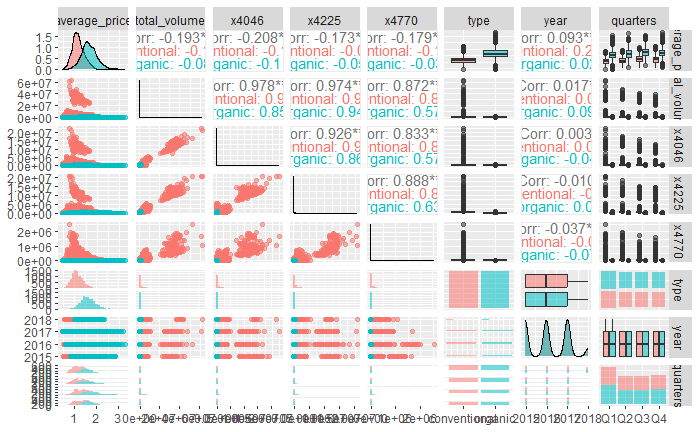

```r
avocado_trim2 %>%
  ggpairs(aes(colour = type, alpha = 0.5))
```

The first interpretation of this plot suggest a strong statistical significance between the average price of avocados with year, any kind of size and total volume.But the correlation is weak even if it is positive or negative.Also, this correlation depends if the origin of the avocado is ‘conventional’ or ‘organic’. If the type is organic the average price is sensible higher than conventional in any quarter of the year, specially in the third one(July- September). The strong significant relationship and the better correlation is between the total_volume and the avocado sells by size x4046, x4225, x4770 overall in conventional but also in the organic type The negative correlation could be interpreted as the average_price of avocados decrease as the total number of avocados available (in the market) increase.

```r
# Only for curiosity as I was not able to do a ggpairs of the all dataset
model_general <- lm(average_price ~., data = avocado_trim)

summary(model_general)
```

```
Call:
lm(formula = average_price ~ ., data = avocado_trim)

Residuals:
     Min       1Q   Median       3Q      Max
-1.06028 -0.14792 -0.00279  0.14763  1.49103

Coefficients: (3 not defined because of singularities)
                            Estimate Std. Error t value Pr(>|t|)
(Intercept)               -1.179e+02  4.131e+00 -28.543  < 2e-16
total_volume              -2.790e-05  3.810e-05  -0.732 0.464109
x4046                      2.791e-05  3.810e-05   0.732 0.463973
x4225                      2.788e-05  3.810e-05   0.732 0.464332
x4770                      2.792e-05  3.810e-05   0.733 0.463695
total_bags                -2.536e-02  2.853e-02  -0.889 0.374111
small_bags                 2.539e-02  2.853e-02   0.890 0.373588
large_bags                 2.539e-02  2.853e-02   0.890 0.373589
x_large_bags               2.539e-02  2.853e-02   0.890 0.373567
typeorganic                4.924e-01  3.861e-03 127.538  < 2e-16
year                       5.914e-02  2.049e-03  28.864  < 2e-16
regionAtlanta             -2.229e-01  1.898e-02 -11.743  < 2e-16
regionBaltimoreWashington -2.371e-02  1.900e-02  -1.248 0.212034
regionBoise               -2.132e-01  1.897e-02 -11.236  < 2e-16
regionBoston              -2.697e-02  1.899e-02  -1.420 0.155670
regionBuffaloRochester    -4.402e-02  1.897e-02  -2.321 0.020316
regionCalifornia          -1.716e-01  1.940e-02  -8.843  < 2e-16
regionCharlotte            4.488e-02  1.897e-02   2.365 0.018026
regionChicago             -3.340e-03  1.907e-02  -0.175 0.860936
regionCincinnatiDayton    -3.499e-01  1.898e-02 -18.433  < 2e-16
regionColumbus            -3.091e-01  1.897e-02 -16.297  < 2e-16
regionDallasFtWorth       -4.761e-01  1.901e-02 -25.051  < 2e-16
regionDenver              -3.351e-01  1.908e-02 -17.561  < 2e-16
regionDetroit             -2.900e-01  1.901e-02 -15.260  < 2e-16
regionGrandRapids         -5.828e-02  1.897e-02  -3.072 0.002130
regionGreatLakes          -2.258e-01  1.970e-02 -11.460  < 2e-16
regionHarrisburgScranton  -4.765e-02  1.897e-02  -2.512 0.011997
regionHartfordSpringfield  2.590e-01  1.897e-02  13.653  < 2e-16
regionHouston             -5.118e-01  1.900e-02 -26.937  < 2e-16
regionIndianapolis        -2.468e-01  1.897e-02 -13.010  < 2e-16
regionJacksonville        -5.008e-02  1.897e-02  -2.640 0.008300
```

[output cut: 117 more lines]

```
month_enter^6             ***
month_enter^7
month_enter^8             *
month_enter^9             *
month_enter^10            **
month_enter^11            *
quartersQ2
quartersQ3
quartersQ4
---
Signif. codes:  0 ‘***’ 0.001 ‘**’ 0.01 ‘*’ 0.05 ‘.’ 0.1 ‘ ’ 1

Residual standard error: 0.2465 on 18174 degrees of freedom
Multiple R-squared:  0.6267,    Adjusted R-squared:  0.6251
F-statistic: 412.2 on 74 and 18174 DF,  p-value: < 2.2e-16
```

A linear model about the relation of the average_price of avocado with all the variable from data set shows that with a positive correlation are year, region ( no all of them),the organic type and finally, size.

First predictor Average_price- year

```r
model1 <- lm(average_price ~ year, data = avocado_trim2)

model1
```

```
Call:
lm(formula = average_price ~ year, data = avocado_trim2)

Coefficients:
(Intercept)         year
  -79.09129      0.03993
```

```r
summary(model1)
```

```
Call:
lm(formula = average_price ~ year, data = avocado_trim2)

Residuals:
     Min       1Q   Median       3Q      Max
-1.00000 -0.30007 -0.04007  0.25985  1.84993

Coefficients:
              Estimate Std. Error t value Pr(>|t|)
(Intercept) -79.091294   6.366332  -12.42   <2e-16 ***
year          0.039926   0.003158   12.64   <2e-16 ***
---
Signif. codes:  0 ‘***’ 0.001 ‘**’ 0.01 ‘*’ 0.05 ‘.’ 0.1 ‘ ’ 1

Residual standard error: 0.4009 on 18247 degrees of freedom
Multiple R-squared:  0.008686,  Adjusted R-squared:  0.008631
F-statistic: 159.9 on 1 and 18247 DF,  p-value: < 2.2e-16
```

As it was mentioned before, there is a significant relationship between year and average_price. However, r-square point out that only a 0.8% in the variance of the average_price is based in year; the Residual standard error is 0.4 on - I think- to high degrees of freedom, that indicates the average error on predicting the average price is 0.4.

Plot model1

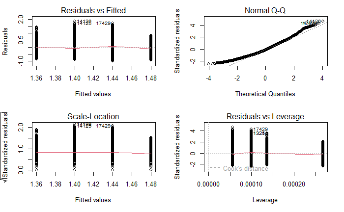

```r
par(mfrow = c(2,2))

plot(model1)
```

The Residuals vs Fitted plot looks strange because there is no a well variation (I would say no well sorted). It makes me think in a variation by quarters, the same for the rest plots where the variation is to vertical. By contrast, I would say the the Q-Q plot is correct with a normal distribution.

Another predictor, Average_price - total_volume

```r
model2 <- lm(average_price ~ total_volume, data = avocado_trim2)

summary(model2)
```

```
Call:
lm(formula = average_price ~ total_volume, data = avocado_trim2)

Residuals:
     Min       1Q   Median       3Q      Max
-0.98366 -0.29994 -0.03319  0.25498  1.82528

Coefficients:
               Estimate Std. Error t value Pr(>|t|)
(Intercept)   1.425e+00  3.012e-03  473.07   <2e-16 ***
total_volume -2.247e-08  8.470e-10  -26.54   <2e-16 ***
---
Signif. codes:  0 ‘***’ 0.001 ‘**’ 0.01 ‘*’ 0.05 ‘.’ 0.1 ‘ ’ 1

Residual standard error: 0.3951 on 18247 degrees of freedom
Multiple R-squared:  0.03715,   Adjusted R-squared:  0.0371
F-statistic: 704.1 on 1 and 18247 DF,  p-value: < 2.2e-16
```

There is a significant relationship between average_price and total_volume. The r-square point out that only a 3% in the variance of the average_price is based in volume; the Residual standard error is 0.395 on - I think- to high degrees of freedom, that indicates the average error on predicting the average price is 0.395.

I think that total_volume is a better predictor for the avocado average_price than the year.

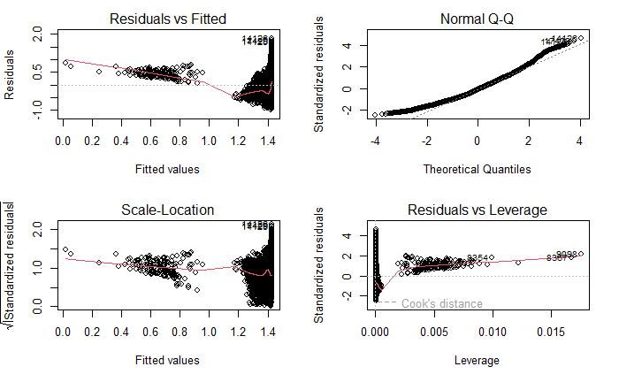

```r
par(mfrow = c(2, 2))
plot(model2)
```

## I think that the normal Q-Q plot is fine and marks the tendency

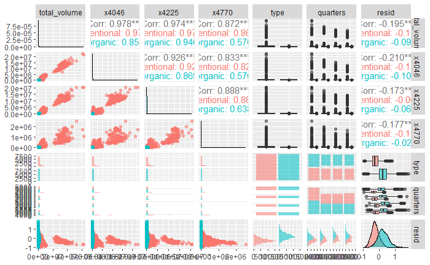

```r
avocado_residuals <- avocado_trim2 %>%
  add_residuals(model1) %>%
  select(-c('average_price','year'))



avocado_residuals %>%
  ggpairs(aes(colour = type, alpha = 0.5))
```

All the relations between the predictors and the residuals are negative, that means, if the predictor increase the residual should decrease.

```r
# Is it better, with 3?


model3 <- lm(average_price ~ total_volume + type, data =  avocado_trim2)


summary(model3)
```

```
Call:
lm(formula = average_price ~ total_volume + type, data = avocado_trim2)

Residuals:
     Min       1Q   Median       3Q      Max
-1.21390 -0.20314 -0.02548  0.18575  1.59581

Coefficients:
               Estimate Std. Error t value Pr(>|t|)
(Intercept)   1.168e+00  3.509e-03 332.878   <2e-16 ***
total_volume -6.115e-09  6.978e-10  -8.763   <2e-16 ***
typeorganic   4.861e-01  4.819e-03 100.872   <2e-16 ***
---
Signif. codes:  0 ‘***’ 0.001 ‘**’ 0.01 ‘*’ 0.05 ‘.’ 0.1 ‘ ’ 1

Residual standard error: 0.3166 on 18246 degrees of freedom
Multiple R-squared:  0.3819,    Adjusted R-squared:  0.3818
F-statistic:  5636 on 2 and 18246 DF,  p-value: < 2.2e-16
```

It looks like that r-square is increasing with the predictors of total_volume and type. in model2 (average_price ~ total_volume) is 0.03715, and model3 (average_price ~ total_volume + type) is 0.3819

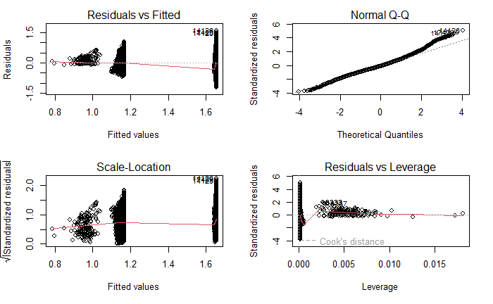

```r
par(mfrow = c(2, 2))
plot(model3)
```

The plots from model3 (average_price ~ total_volume + type) are quite similar to the plot from model2(average_price ~ total_volume).

models. model_general (all the predictors) Multiple R-squared: 0.6267 model1 (average_price ~ year) Multiple R-squared: 0.008686 model2 (average_price ~ total_volume) Multiple R-squared: 0.03715 model3 (average_price ~ total_volume + type) Multiple R-squared: 0.3819

Process Anova to decide if the categorical predictor is significant. model_general and model3 are the best

```r
anova(model_general,model3)
```

```
Analysis of Variance Table

Model 1: average_price ~ total_volume + x4046 + x4225 + x4770 + total_bags +
    small_bags + large_bags + x_large_bags + type + year + region +
    month_enter + quarters
Model 2: average_price ~ total_volume + type
  Res.Df    RSS  Df Sum of Sq     F    Pr(>F)
1  18174 1104.7
2  18246 1829.0 -72   -724.31 165.5 < 2.2e-16 ***
---
Signif. codes:  0 ‘***’ 0.001 ‘**’ 0.01 ‘*’ 0.05 ‘.’ 0.1 ‘ ’ 1
```

```r
#Perhaps, I should not do this
```

3 -predictor.

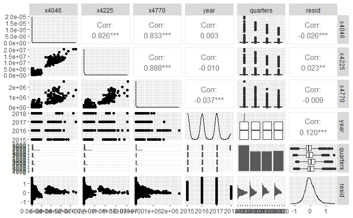

```r
avocado_residuals2 <- avocado_trim2 %>%
  add_residuals(model3) %>%
  select(-c('average_price','total_volume','type'))


avocado_residuals2 %>%
  ggpairs()
```

```r
model4 <- lm(average_price ~ total_volume + type + year, data = avocado_trim2)

summary(model4)
```

```
Call:
lm(formula = average_price ~ total_volume + type + year, data = avocado_trim2)

Residuals:
     Min       1Q   Median       3Q      Max
-1.24827 -0.19862 -0.01915  0.18839  1.60177

Coefficients:
               Estimate Std. Error t value Pr(>|t|)
(Intercept)  -8.015e+01  4.992e+00 -16.055   <2e-16 ***
total_volume -6.314e-09  6.929e-10  -9.113   <2e-16 ***
typeorganic   4.858e-01  4.785e-03 101.533   <2e-16 ***
year          4.033e-02  2.476e-03  16.289   <2e-16 ***
---
Signif. codes:  0 ‘***’ 0.001 ‘**’ 0.01 ‘*’ 0.05 ‘.’ 0.1 ‘ ’ 1

Residual standard error: 0.3143 on 18245 degrees of freedom
Multiple R-squared:  0.3907,    Adjusted R-squared:  0.3906
F-statistic:  3900 on 3 and 18245 DF,  p-value: < 2.2e-16
```

The r-square in the model4 is a slightly higher than model3 but very low from model_general. All the predictors are strongly significant for statistical purposes.

Check by Anova if model4 is better than model2

```r
anova(model2,model4)
```

```
Analysis of Variance Table

Model 1: average_price ~ total_volume
Model 2: average_price ~ total_volume + type + year
  Res.Df    RSS Df Sum of Sq    F    Pr(>F)
1  18247 2848.9
2  18245 1802.8  2    1046.2 5294 < 2.2e-16 ***
---
Signif. codes:  0 ‘***’ 0.001 ‘**’ 0.01 ‘*’ 0.05 ‘.’ 0.1 ‘ ’ 1
```

model4 is significant and it has a low p-value, type and year are significant.

Possible interaction between 2 independent variables?

```r
avocado_residuals3 <- avocado_trim2 %>%
  add_residuals(model4) %>%
  select(-'average_price')
```

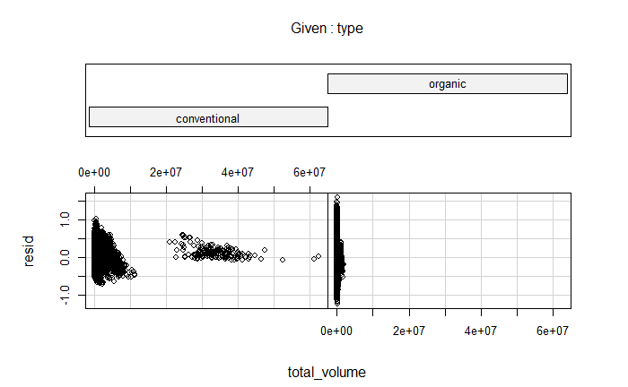

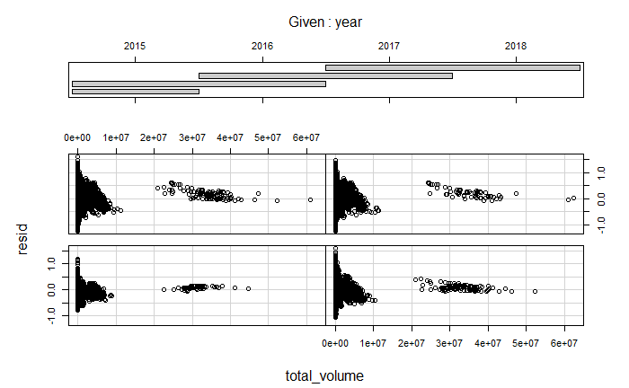

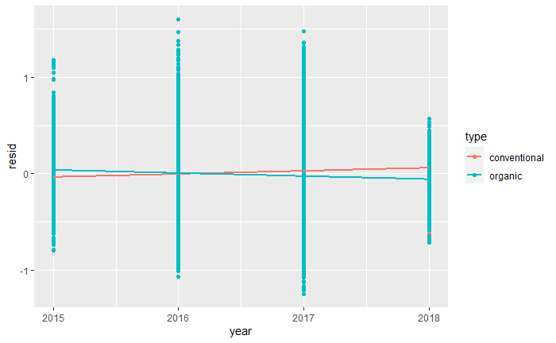

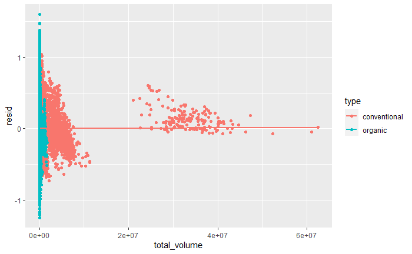

In the first plot year-residuals the line is around 0, with light variation. The second plot is a straight line in 0 by the conventional avocado, which I guess can be related with the first plot(ggpairs) where the max peak of cost on average_avocado was by conventional, although the cost of organic were higher.

Over_fit the avocado model, I will use avocado_trim, also, average_price.Avocado_trim has the ’ region’ variable and I would like to see how its working.

```r
summary(model_overfit)
```

```
Call:
lm(formula = average_price ~ ., data = avocado_trim)

Residuals:
     Min       1Q   Median       3Q      Max
-1.06028 -0.14792 -0.00279  0.14763  1.49103

Coefficients: (3 not defined because of singularities)
                            Estimate Std. Error t value Pr(>|t|)
(Intercept)               -1.179e+02  4.131e+00 -28.543  < 2e-16
total_volume              -2.790e-05  3.810e-05  -0.732 0.464109
x4046                      2.791e-05  3.810e-05   0.732 0.463973
x4225                      2.788e-05  3.810e-05   0.732 0.464332
x4770                      2.792e-05  3.810e-05   0.733 0.463695
total_bags                -2.536e-02  2.853e-02  -0.889 0.374111
small_bags                 2.539e-02  2.853e-02   0.890 0.373588
large_bags                 2.539e-02  2.853e-02   0.890 0.373589
x_large_bags               2.539e-02  2.853e-02   0.890 0.373567
typeorganic                4.924e-01  3.861e-03 127.538  < 2e-16
year                       5.914e-02  2.049e-03  28.864  < 2e-16
regionAtlanta             -2.229e-01  1.898e-02 -11.743  < 2e-16
regionBaltimoreWashington -2.371e-02  1.900e-02  -1.248 0.212034
regionBoise               -2.132e-01  1.897e-02 -11.236  < 2e-16
regionBoston              -2.697e-02  1.899e-02  -1.420 0.155670
regionBuffaloRochester    -4.402e-02  1.897e-02  -2.321 0.020316
regionCalifornia          -1.716e-01  1.940e-02  -8.843  < 2e-16
regionCharlotte            4.488e-02  1.897e-02   2.365 0.018026
regionChicago             -3.340e-03  1.907e-02  -0.175 0.860936
regionCincinnatiDayton    -3.499e-01  1.898e-02 -18.433  < 2e-16
regionColumbus            -3.091e-01  1.897e-02 -16.297  < 2e-16
regionDallasFtWorth       -4.761e-01  1.901e-02 -25.051  < 2e-16
regionDenver              -3.351e-01  1.908e-02 -17.561  < 2e-16
regionDetroit             -2.900e-01  1.901e-02 -15.260  < 2e-16
regionGrandRapids         -5.828e-02  1.897e-02  -3.072 0.002130
regionGreatLakes          -2.258e-01  1.970e-02 -11.460  < 2e-16
regionHarrisburgScranton  -4.765e-02  1.897e-02  -2.512 0.011997
regionHartfordSpringfield  2.590e-01  1.897e-02  13.653  < 2e-16
regionHouston             -5.118e-01  1.900e-02 -26.937  < 2e-16
regionIndianapolis        -2.468e-01  1.897e-02 -13.010  < 2e-16
regionJacksonville        -5.008e-02  1.897e-02  -2.640 0.008300
```

[output cut: 117 more lines]

```
month_enter^6             ***
month_enter^7
month_enter^8             *
month_enter^9             *
month_enter^10            **
month_enter^11            *
quartersQ2
quartersQ3
quartersQ4
---
Signif. codes:  0 ‘***’ 0.001 ‘**’ 0.01 ‘*’ 0.05 ‘.’ 0.1 ‘ ’ 1

Residual standard error: 0.2465 on 18174 degrees of freedom
Multiple R-squared:  0.6267,    Adjusted R-squared:  0.6251
F-statistic: 412.2 on 74 and 18174 DF,  p-value: < 2.2e-16
```

```r
summary(model_wellfit)
```

```
Call:
lm(formula = average_price ~ total_volume + type + year + region,
    data = avocado_trim)

Residuals:
     Min       1Q   Median       3Q      Max
-1.09029 -0.16457 -0.01002  0.14707  1.48099

Coefficients:
                            Estimate Std. Error t value Pr(>|t|)
(Intercept)               -7.960e+01  4.267e+00 -18.657  < 2e-16
total_volume              -3.256e-09  8.453e-10  -3.852 0.000118
typeorganic                4.907e-01  4.202e-03 116.772  < 2e-16
year                       4.014e-02  2.116e-03  18.965  < 2e-16
regionAtlanta             -2.224e-01  2.066e-02 -10.762  < 2e-16
regionBaltimoreWashington -2.566e-02  2.067e-02  -1.242 0.214325
regionBoise               -2.129e-01  2.066e-02 -10.304  < 2e-16
regionBoston              -2.937e-02  2.066e-02  -1.421 0.155301
regionBuffaloRochester    -4.413e-02  2.066e-02  -2.136 0.032697
regionCalifornia          -1.560e-01  2.082e-02  -7.491 7.12e-14
regionCharlotte            4.519e-02  2.066e-02   2.187 0.028763
regionChicago             -3.127e-03  2.066e-02  -0.151 0.879716
regionCincinnatiDayton    -3.516e-01  2.066e-02 -17.014  < 2e-16
regionColumbus            -3.081e-01  2.066e-02 -14.912  < 2e-16
regionDallasFtWorth       -4.736e-01  2.067e-02 -22.914  < 2e-16
regionDenver              -3.413e-01  2.067e-02 -16.514  < 2e-16
regionDetroit             -2.845e-01  2.066e-02 -13.768  < 2e-16
regionGrandRapids         -5.590e-02  2.066e-02  -2.705 0.006831
regionGreatLakes          -2.170e-01  2.071e-02 -10.475  < 2e-16
regionHarrisburgScranton  -4.750e-02  2.066e-02  -2.299 0.021518
regionHartfordSpringfield  2.579e-01  2.066e-02  12.483  < 2e-16
regionHouston             -5.113e-01  2.067e-02 -24.739  < 2e-16
regionIndianapolis        -2.469e-01  2.066e-02 -11.949  < 2e-16
regionJacksonville        -4.997e-02  2.066e-02  -2.418 0.015609
regionLasVegas            -1.797e-01  2.066e-02  -8.699  < 2e-16
regionLosAngeles          -3.403e-01  2.070e-02 -16.440  < 2e-16
regionLouisville          -2.743e-01  2.066e-02 -13.277  < 2e-16
regionMiamiFtLauderdale   -1.318e-01  2.066e-02  -6.376 1.86e-10
regionMidsouth            -1.515e-01  2.070e-02  -7.320 2.57e-13
regionNashville           -3.487e-01  2.066e-02 -16.878  < 2e-16
```

[output cut: 76 more lines]

```
regionSouthCentral        ***
regionSoutheast           ***
regionSpokane             ***
regionStLouis             ***
regionSyracuse            *
regionTampa               ***
regionTotalUS             ***
regionWest                ***
regionWestTexNewMexico    ***
---
Signif. codes:  0 ‘***’ 0.001 ‘**’ 0.01 ‘*’ 0.05 ‘.’ 0.1 ‘ ’ 1

Residual standard error: 0.2686 on 18192 degrees of freedom
Multiple R-squared:  0.5564,    Adjusted R-squared:  0.555
F-statistic: 407.4 on 56 and 18192 DF,  p-value: < 2.2e-16
```

The r -square is better in the overfit model than in the wellfit model.

```r
summary(model_underfit)
```

```
Call:
lm(formula = average_price ~ total_volume, data = avocado_trim)

Residuals:
     Min       1Q   Median       3Q      Max
-0.98366 -0.29994 -0.03319  0.25498  1.82528

Coefficients:
               Estimate Std. Error t value Pr(>|t|)
(Intercept)   1.425e+00  3.012e-03  473.07   <2e-16 ***
total_volume -2.247e-08  8.470e-10  -26.54   <2e-16 ***
---
Signif. codes:  0 ‘***’ 0.001 ‘**’ 0.01 ‘*’ 0.05 ‘.’ 0.1 ‘ ’ 1

Residual standard error: 0.3951 on 18247 degrees of freedom
Multiple R-squared:  0.03715,   Adjusted R-squared:  0.0371
F-statistic: 704.1 on 1 and 18247 DF,  p-value: < 2.2e-16
```

```r
AIC(model_overfit)
```

```
[1] 760.0694
```

```r
AIC(model_wellfit)
```

```
[1] 3871.933
```

```r
AIC(model_underfit)
```

```
[1] 17903.12
```

The model_overfit present the lower AIC, so it is a good model. But I am going to check more in-depth.

| r.squared | adj.r.squared | AIC | BIC |
| --- | --- | --- | --- |
| 0.6266572 | 0.6251371 | 760.0694 | 1353.771 |

| r.squared | adj.r.squared | AIC | BIC |
| --- | --- | --- | --- |
| 0.5563695 | 0.5550038 | 3871.933 | 4325.021 |

| r.squared | adj.r.squared | AIC | BIC |
| --- | --- | --- | --- |
| 0.03715348 | 0.03710072 | 17903.12 | 17926.55 |

In fact, the model_overfit present the best results. Something is not right